# **Ford Go-bike** Dataset Exploration Project

### Plotting Clustered Bar Charts and Heat maps

> (Plot two qualitative variables)

Plotting Clustered Bar Chart between `member_gender` and `bike_share_for_all_trip`

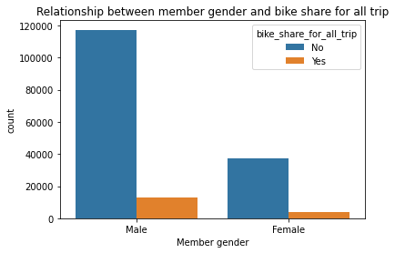

```python
#Clustered Bar Charts between 'member_gender' and 'bike_share_for_all_trip'
sb.countplot(data = bike, x = 'member_gender', hue = 'bike_share_for_all_trip')
plt.xlabel('Member gender')
plt.title('Relationship between member gender and bike share for all trip', fontsize=12);
```

Plotting heat map between `member_gender` and `bike_share_for_all_trip`

```python
# Use group_by() and size() to get the number of bike shares for all trips and each combination of the two variable levels as a pandas Series
share_counts = bike.groupby(['member_gender', 'bike_share_for_all_trip']).size()

# Use Series.reset_index() to convert a series into a dataframe object
share_counts = share_counts.reset_index(name='count')
share_counts

# Use DataFrame.pivot() to rearrange the data, to have member gender on rows
share_counts = share_counts.pivot(index = 'member_gender', columns = 'bike_share_for_all_trip', values = 'count')
share_counts
```

| bike_share_for_all_trip member_gender | No | Yes |
| --- | --- | --- |
| Female | 37197 | 3594 |
| Male | 117366 | 13077 |

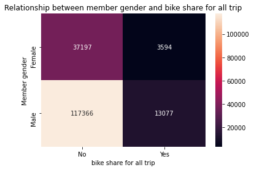

```python
#Plot the heatmap
sb.heatmap(share_counts, annot = True, fmt = 'd')
plt.xlabel('bike share for all trip')
plt.ylabel('Member gender')
plt.title('Relationship between member gender and bike share for all trip', fontsize=12);
```

> - Males and females users have higher counts of no bike sharing in all trips.

Plotting Clustered Bar Chart between `member_gender` and `user_type`

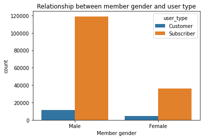

```python
#Clustered Bar Charts
sb.countplot(data = bike, x = 'member_gender', hue = 'user_type')
plt.xlabel('Member gender')
plt.title('Relationship between member gender and user type', fontsize=12);
```

Plotting heat map between `member_gender` and `user_type`

```python
# Use group_by() and size() to get the number of user types and each combination of the two variable levels as a pandas Series
user_counts = bike.groupby(['member_gender', 'user_type']).size()

# Use Series.reset_index() to convert a series into a dataframe object
user_counts = user_counts.reset_index(name='count')
user_counts

# Use DataFrame.pivot() to rearrange the data, to have member gender on rows
user_counts = user_counts.pivot(index = 'member_gender', columns = 'user_type', values = 'count')
user_counts
```

| user_type member_gender | Customer | Subscriber |
| --- | --- | --- |
| Female | 4622 | 36169 |
| Male | 11489 | 118954 |

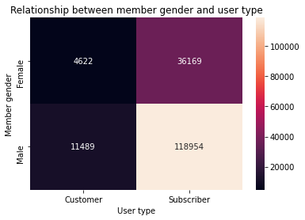

```python
#Plot the heatmap
sb.heatmap(user_counts, annot = True, fmt = 'd')
plt.xlabel('User type')
plt.ylabel('Member gender')
plt.title('Relationship between member gender and user type', fontsize=12);
```

> -Most of male and female users are subscribers.

Plotting Clustered Bar Chart between `user_type` and `bike_share_for_all_trip` columns

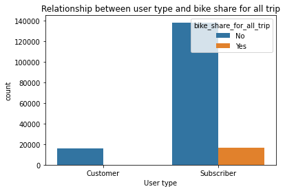

```python
#Clustered Bar Charts
sb.countplot(data = bike, x = 'user_type', hue = 'bike_share_for_all_trip')
plt.xlabel('User type')
plt.title('Relationship between user type and bike share for all trip', fontsize=12);
```

Plotting heat map between `user_type` and `bike_share_for_all_trip` columns

```python
# Use group_by() and size() to get the number of bike_share_for_all_trip and each combination of the two variable levels as a pandas Series
type_counts = bike.groupby(['user_type', 'bike_share_for_all_trip']).size()

# Use Series.reset_index() to convert a series into a dataframe object
type_counts = type_counts.reset_index(name='count')
type_counts

# Use DataFrame.pivot() to rearrange the data, to have user_type on rows
type_counts = type_counts.pivot(index = 'user_type', columns = 'bike_share_for_all_trip', values = 'count')
type_counts
```

| bike_share_for_all_trip user_type | No | Yes |
| --- | --- | --- |
| Customer | 16111.0 | NaN |
| Subscriber | 138452.0 | 16671.0 |

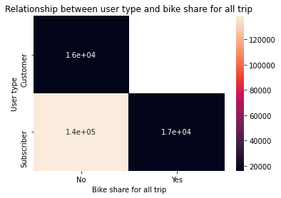

```python
#Plot the heatmap
sb.heatmap(type_counts, annot = True)
plt.ylabel('User type')
plt.xlabel('Bike share for all trip')
plt.title('Relationship between user type and bike share for all trip', fontsize=12);
```

> - No customers use bike share systems for all trips.

### Plotting FacetGrids

Plot FacetGrid between `Start_Date` and `bike_share_for_all_trip` columns

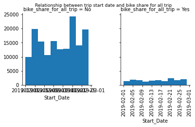

```python
# Specify the figure size in inches, for both X, and Y axes
rcParams['figure.figsize'] = 25,5

# Plot the Seaborn's FacetGrid
g = sb.FacetGrid(data = bike, col = 'bike_share_for_all_trip')
g.map(plt.hist, "Start_Date")

plt.suptitle('Relationship between trip start date and bike share for all trip', fontsize=9)

# Use xticks to rotate the category labels (not axes) counter-clockwise
plt.xticks(rotation = 90);
```

Plot FacetGrid between `Start_Date` and `user_type` columns

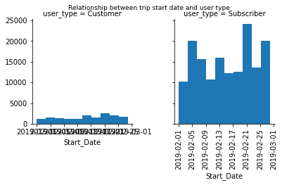

```python
# Specify the figure size in inches, for both X, and Y axes
rcParams['figure.figsize'] = 25,5

# Plot the Seaborn's FacetGrid
g = sb.FacetGrid(data = bike, col = 'user_type')
g.map(plt.hist, "Start_Date")

plt.suptitle('Relationship between trip start date and user type', fontsize=9)

# Use xticks to rotate the category labels (not axes) counter-clockwise
plt.xticks(rotation = 90);
```

Plot FacetGrid between `Start_Date` and `member_gender` columns

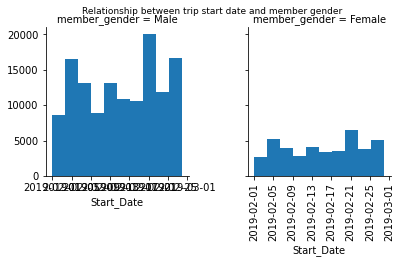

```python
# Specify the figure size in inches, for both X, and Y axes
rcParams['figure.figsize'] = 25,5

# Plot the Seaborn's FacetGrid
g = sb.FacetGrid(data = bike, col = 'member_gender')
g.map(plt.hist, "Start_Date")

plt.suptitle('Relationship between trip start date and member gender', fontsize=9)

# Use xticks to rotate the category labels (not axes) counter-clockwise
plt.xticks(rotation = 90)
```

> - Male subscribers with no bike share for all trips are the most users in working days of the month.

### Line Plots

Line plot for trip duration and member gender

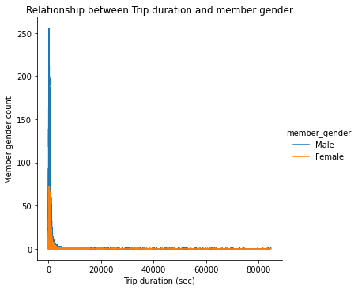

```python
def freq_poly(x, bins = 10, **kwargs):
    """ Custom frequency polygon / line plot code. """
    # set bin edges if none or int specified
    if type(bins) == int:
        bins = np.linspace(x.min(), x.max(), bins+1)
    bin_centers = (bin_edges[1:] + bin_edges[:-1]) / 2

    # compute counts
    data_bins = pd.cut(x, bins, right = False,
                       include_lowest = True)
    counts = x.groupby(data_bins).count()

    # create plot
    plt.errorbar(x = bin_centers, y = counts, **kwargs)

bin_edges = np.arange(60, bike['duration_sec'].max()+1/3, 1/3)
g = sb.FacetGrid(data = bike, hue = 'member_gender', size = 5)
g.map(freq_poly, "duration_sec", bins = bin_edges)
g.add_legend()
plt.xlabel('Trip duration (sec)')
plt.ylabel('Member gender count')
plt.title('Relationship between Trip duration and member gender', fontsize=12);
```

> - Males are biking more than females

Line plot for member birth year and member gender

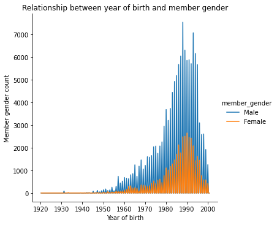

```python
def freq_poly(x, bins = 10, **kwargs):
    """ Custom frequency polygon / line plot code. """
    # set bin edges if none or int specified
    if type(bins) == int:
        bins = np.linspace(x.min(), x.max(), bins+1)
    bin_centers = (bin_edges[1:] + bin_edges[:-1]) / 2

    # compute counts
    data_bins = pd.cut(x, bins, right = False,
                       include_lowest = True)
    counts = x.groupby(data_bins).count()

    # create plot
    plt.errorbar(x = bin_centers, y = counts, **kwargs)

bin_edges = np.arange(1920, bike['member_birth_year'].max()+1/3, 1/3)
g = sb.FacetGrid(data = bike, hue = 'member_gender', size = 5)
g.map(freq_poly, "member_birth_year", bins = bin_edges)
g.add_legend()
plt.xlabel('Year of birth')
plt.ylabel('Member gender count')
plt.title('Relationship between year of birth and member gender', fontsize=12);
```

> - Most of bike riders were born after 1980, and most of them are males.

Line plot for member birth year and user type

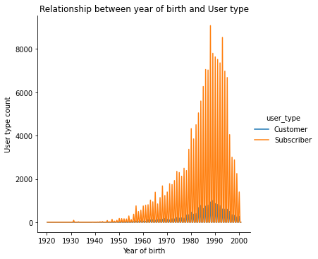

```python
def freq_poly(x, bins = 10, **kwargs):
    """ Custom frequency polygon / line plot code. """
    # set bin edges if none or int specified
    if type(bins) == int:
        bins = np.linspace(x.min(), x.max(), bins+1)
    bin_centers = (bin_edges[1:] + bin_edges[:-1]) / 2

    # compute counts
    data_bins = pd.cut(x, bins, right = False,
                       include_lowest = True)
    counts = x.groupby(data_bins).count()

    # create plot
    plt.errorbar(x = bin_centers, y = counts, **kwargs)

bin_edges = np.arange(1920, bike['member_birth_year'].max()+1/3, 1/3)
g = sb.FacetGrid(data = bike, hue = 'user_type', size = 5)
g.map(freq_poly, "member_birth_year", bins = bin_edges)
g.add_legend()
plt.xlabel('Year of birth')
plt.ylabel('User type count')
plt.title('Relationship between year of birth and User type', fontsize=12);
```

> Subscribers are more than cutomers

Line plot for member birth year and bike share for all trip

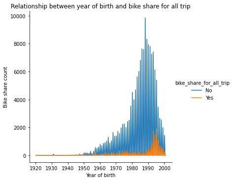

```python
def freq_poly(x, bins = 10, **kwargs):
    """ Custom frequency polygon / line plot code. """
    # set bin edges if none or int specified
    if type(bins) == int:
        bins = np.linspace(x.min(), x.max(), bins+1)
    bin_centers = (bin_edges[1:] + bin_edges[:-1]) / 2

    # compute counts
    data_bins = pd.cut(x, bins, right = False,
                       include_lowest = True)
    counts = x.groupby(data_bins).count()

    # create plot
    plt.errorbar(x = bin_centers, y = counts, **kwargs)

bin_edges = np.arange(1920, bike['member_birth_year'].max()+1/3, 1/3)
g = sb.FacetGrid(data = bike, hue = 'bike_share_for_all_trip', size = 5)
g.map(freq_poly, "member_birth_year", bins = bin_edges)
g.add_legend()
plt.xlabel('Year of birth')
plt.ylabel('Bike share count')
plt.title('Relationship between year of birth and bike share for all trip', fontsize=12);
```

> - Many users born in 90s use bike share system for all trip more than others users.

### Talk about some of the relationships you observed in this part of the investigation. How did the feature(s) of interest vary with other features in the dataset?

> - The relationship between user's year of birth and trip duration is positive because as year of birth is higher, the values of the trip duration are increasing.
> - Most of the trips are short ones. -Violin and Box plots indicated the presence of vast ranges of outliers in trip durations.
> - Most of male and female users are subscribers.
> - Male subscribers with no bike share for all trips are the most users in working days of the month.
> - Most of bike riders were born after 1980, and most of them are males.

### Did you observe any interesting relationships between the other features (not the main feature(s) of interest)?

> - Many subscribers born in 90s use bike share system for all trip more than other users.
> - Customers never use bike share system for all trip at all.

## Multivariate Exploration

> Creating plots of three or more variables to investigate data even further.

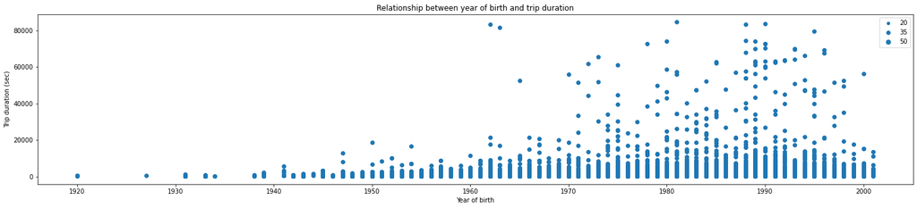

```python
plt.scatter(data = bike, x = 'member_birth_year', y = 'duration_sec')

# dummy series for adding legend
sizes = [20, 35, 50]
base_color = sb.color_palette()[0]
legend_obj = []
for s in sizes:
    legend_obj.append(plt.scatter([], [], s = s, color = base_color))
plt.legend(legend_obj, sizes)

plt.xlabel('Year of birth')
plt.ylabel('Trip duration (sec)')
plt.title('Relationship between year of birth and trip duration', fontsize=12);
```

> - The previous graph is not indicative.
> - Another type of graphs will be used to be more clear.

#### Scatter Plot with Shape encoding: Two numeric variables and one categorical variable (Nominal)

Scatter plot between year of birth, trip duration, and member gender

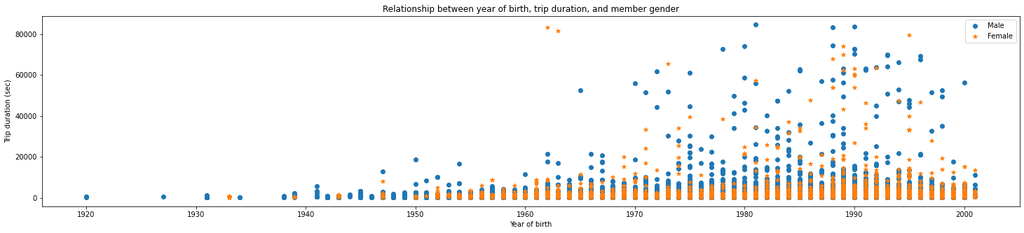

```python
# Scatter plot between year of birth, trip duration, and member gender

cat_markers = [['Male', 'o'],
               ['Female', '*']]

for cat, marker in cat_markers:
    df_cat = bike[bike['member_gender'] == cat]
    plt.scatter(data = df_cat, x = 'member_birth_year', y = 'duration_sec', marker = marker)
plt.legend(['Male','Female'])

plt.xlabel('Year of birth')
plt.ylabel('Trip duration (sec)')
plt.title('Relationship between year of birth, trip duration, and member gender', fontsize=12);
```

- Young Males go for more longer trips than females

Scatter plot between year of birth, trip duration, and bike_share_for_all_trip

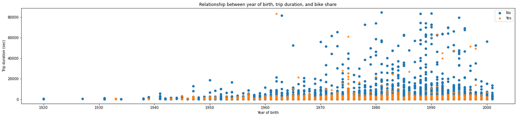

```python
# Scatter plot between year of birth, trip duration, and bike_share_for_all_trip

cat_markers = [['No', 'o'],
               ['Yes', '*']]

for cat, marker in cat_markers:
    df_cat = bike[bike['bike_share_for_all_trip'] == cat]
    plt.scatter(data = df_cat, x = 'member_birth_year', y = 'duration_sec', marker = marker)
plt.legend(['No','Yes'])

plt.xlabel('Year of birth')
plt.ylabel('Trip duration (sec)')
plt.title('Relationship between year of birth, trip duration, and bike share', fontsize=12);
```

> - Bike share for all trip is mostly used for short trip durations

Scatter plot between year of birth, trip duration, and user type

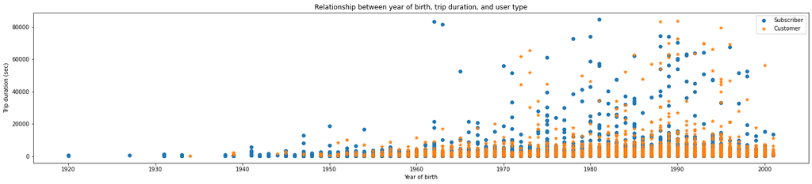

```python
# Scatter plot between year of birth, trip duration, and user type

cat_markers = [['Subscriber', 'o'],
               ['Customer', '*']]

for cat, marker in cat_markers:
    df_cat = bike[bike['user_type'] == cat]
    plt.scatter(data = df_cat, x = 'member_birth_year', y = 'duration_sec', marker = marker)
plt.legend(['Subscriber','Customer'])

plt.xlabel('Year of birth')
plt.ylabel('Trip duration (sec)')
plt.title('Relationship between year of birth, trip duration, and user type', fontsize=12);
```

> - Youger aged subscribers and customers ride for longer trips than old aged users.

### Faceted grid on different levels of variables

Faceted grid on days of trip start variable

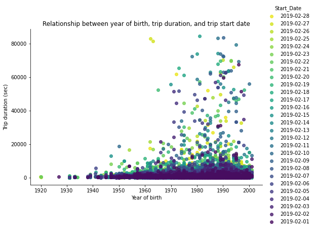

```python
# create faceted plot on start date of trips
g = sb.FacetGrid(data = bike, hue = 'Start_Date', size = 5, aspect = 1.5, palette='viridis_r')
g.map(sb.regplot, 'member_birth_year', 'duration_sec', x_jitter = 0.04, fit_reg = False)
g.add_legend()

plt.xlabel('Year of birth')
plt.ylabel('Trip duration (sec)')
plt.title('Relationship between year of birth, trip duration, and trip start date', fontsize=12);
```

Faceted grid on member gender variable

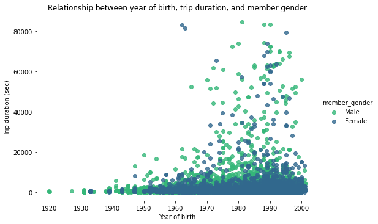

```python
g = sb.FacetGrid(data = bike, hue = 'member_gender', size = 5, aspect = 1.5, palette='viridis_r')
g.map(sb.regplot, 'member_birth_year', 'duration_sec', x_jitter = 0.04, fit_reg = False)
g.add_legend()

plt.xlabel('Year of birth')
plt.ylabel('Trip duration (sec)')
plt.title('Relationship between year of birth, trip duration, and member gender', fontsize=12);
```

> - Males take longer bike trips than females, especially young aged users.

### Faceting : Create multi plots instead of encoding in one plot

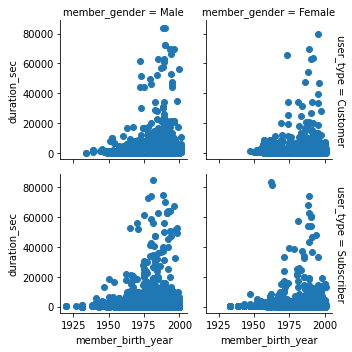

```python
g = sb.FacetGrid(data = bike, col = 'member_gender', row = 'user_type', size = 2.5,
                margin_titles = True)
g.map(plt.scatter, 'member_birth_year', 'duration_sec')
```

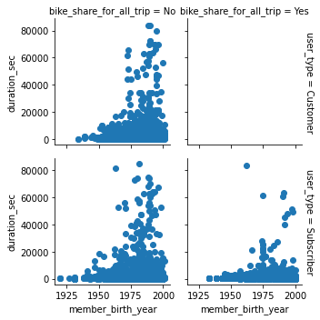

```python
g = sb.FacetGrid(data = bike, col = 'bike_share_for_all_trip', row = 'user_type', size = 2.5,
                margin_titles = True)
g.map(plt.scatter, 'member_birth_year', 'duration_sec')
```

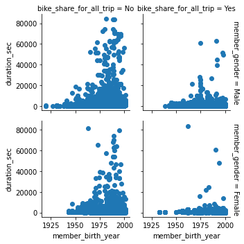

```python
g = sb.FacetGrid(data = bike, col = 'bike_share_for_all_trip', row = 'member_gender', size = 2.5,
                margin_titles = True)
g.map(plt.scatter, 'member_birth_year', 'duration_sec')
```

### Talk about some of the relationships you observed in this part of the investigation. Were there features that strengthened each other in terms of looking at your feature(s) of interest?

> - Young Males go for more longer trips than females.
> - Bike share for all trip is mostly used for short trip durations.
> - Youger aged subscribers and customers ride for longer trips than old aged users.

### Were there any interesting or surprising interactions between features?

> - Male users are more commonly to take exceptionally long bike trips.